# FINAL_POS

## Il classificatore Baesyano come approccio linguistico alla individuazione automatica delle Fake News pt.1

L'elaborato nasce dalla volontà di scoprire, utilizzando algoritmi di machine learning e data mining, quali sono gli attributi caratteristici delle fake news, e se vi sono metodi automatici per capire se un testo è falso o vero.

L'obbiettivo di questo progetto è quello di allenare un classificatore Baesyano su un dataset di notizie, composto da due fold: uno di fake news, e l'altro di notizie vere, ponendosi come vincolo l'attuazione di tutte le strategie per rendere il risultato il più accurato e robusto possibile.

Il dataset utilizzato è interamente in lingua inglese ed è stato creato utilizzando snopes come fonte, visto l'autorità affermata del sito.

La classificazione avverà su due base dati: la prima, sarà il dataset non pre-processato, mentre la seconda sarà utilizzando tutti gli accorgimenti per disambiguare le parole all'interno del testo (Tokenizzazione - POS Tagging - Lemmatizzazione)

Questa seconda analisi viene effettuata su una classificazione con preprocessing, nella quale verranno analizzati gli articoli manipolati: essi infatti subiranno un processo di tokenizzazione (verranno eliminati gli spazi), un processo di POS Tagging (ovvero verrà applicato un tag specifico a ogni parola in base alla sua posizione all'interno della frase) e un processo di lemmatizzazione (ovvero ogni parola verrà ridotta alla sua forma canonica). Questo preprocessing si prevede aumenterà il carattere informativo di ogni feature: sopratutto in lingua inglese infatti, la stessa parola può avere significati diversi, quindi differenziandone le varie sfumature di significato, si potrà avere un potere di generalizazione migliore.

```python
import nltk
from nltk import *
from nltk.corpus.reader import CategorizedPlaintextCorpusReader
from nltk.corpus import wordnet as wn
import pandas as pd
import re, string
from nltk.stem import WordNetLemmatizer
from __future__ import print_function

wnl = WordNetLemmatizer()

def univ_pos_changer(stringa):
    if stringa=="NOUN":
        return "n"
    elif stringa=="VERB":
        return "v"
    elif stringa=="ADJ":
        return "a"
    elif stringa=="ADV":
        return "r"
    else:
        return None

def my_lemmatizer(frase):
    lista1 = []
    for parole in frase:
        word =parole.split("__")[0].lower()
        tag = parole.split("__")[1]

        if univ_pos_changer(tag) == None:
            lista1.append(wnl.lemmatize(word.replace("_",""))+"__"+tag)
        elif(wn.morphy(word,univ_pos_changer(tag)) == None):
            lista1.append(wnl.lemmatize(word.replace("_",""))+"__"+tag)
        else:
            lista1.append(wn.morphy(word,univ_pos_changer(tag))+"__"+tag)
    return lista1
```

```python
import nltk
from nltk import *
import random
from nltk.corpus.reader import CategorizedPlaintextCorpusReader

file = "snopes/dataset"
collCategorized= CategorizedPlaintextCorpusReader(file, r'.*\.txt', cat_pattern=r'(\w+)/*')
documents1 =[(list(collCategorized.words(fileid)), category) for category in collCategorized.categories() for fileid in collCategorized.fileids(category)]

random.shuffle(documents1)
print("Articoli totali: {}".format(len(documents1)))
```

```
Articoli totali: 1127
```

Il caricamento del dataset avviene utilizzando la stessa procedura del programma precedente.

```python
corpus = []
corpus_tagged = []
i = 0;
for j in documents1:
    text = j[0]
    cat = j[1]
    tagged = nltk.pos_tag(word_tokenize(" ".join(text)),tagset="universal")
    corpus.append(([a.replace("_","").replace("_","")+"__"+b.replace("_","") for a,b in tagged],cat))
    corpus_tagged.append((my_lemmatizer(corpus[i][0]),corpus[i][1]))
    i = i+1
    print("\r{}° articoli di {} POS taggati! \r".format(i,len(documents1)), end='')
```

```
1127° articoli di 1127 POS taggati!
```

La tokenizzazione e il POS Tagging avvengono utilizzando le funzioni di nltk. Il delimitatore tra parola è tag è un doppio carattere speciale , che poi sarà lemmatizzato dalla funzione my_lemmatizer() vista in precedenza. Il dataset finale (ovvero corpus_tagged) quindi sarà composto da:

###### [(articolo ,categoria), (articolo1,categoria1) ... (articolon,categorian)]

con articolo compreso di: [parola_tag, parola1_tag1, ... , parolan_tagn]. con articolo s'intende un articolo fisico all'interno del dataset 'Snopes' con parola s'intende un parola all'interno dell'articolo con tag s'intende la particella invariabile del discorso che identifica la parola,  
con categoria s'intende la tipologia d'appartenenza dell'articolo, intesa come 'fake' o 'legit'.

```
TAG analysis on corpus:
```

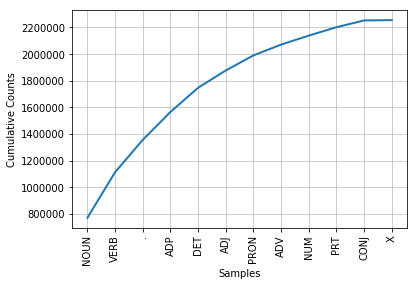

```
  NOUN   VERB      .    ADP    DET    ADJ   PRON    ADV    NUM    PRT   CONJ      X
771258 342264 242760 209404 181488 130049 113105  81005  67511  63002  50835   2462
```

```python
print("TAG analysis on corpus:")
stat = []
count = 0
dev = []
false = []
true = []
while count < len(corpus_tagged):
    if corpus_tagged[count][1]=="legit":
        for i in corpus_tagged[count][0]:
            true.append((i.split("__")[0],i.split("__")[1]))
    if corpus_tagged[count][1]=="fake":
        for i in corpus_tagged[count][0]:
            false.append((i.split("__")[0],i.split("__")[1]))
    for i in corpus_tagged[count][0]:
            stat.append((i.split("__")[0],i.split("__")[1]))
    count = count +1

tag_fd = nltk.FreqDist(tag for (word,tag) in stat)
tag_fd.most_common()
tag_fd.plot(cumulative=True)
tag_fd.tabulate()
```

Il POS tag è avvenuto con successo, e il grafico mostra la distribuzione dei tag all'interno del corpus. Con NOUN s'intende i sostantivi con VERB s'intende verbi lemmatizzati con . s'intende la punteggiatura con ADP s'intende le apposizioni con DET s'intende gli articoli determinativi e indeterminativi con ADJ s'intende gli aggettivi con PRON s'intende i pronomi con ADV s'intende gli avverbi con NUM s'intende le cifre con PRT s'intende le particelle con CONJ s'intende le congiunzioni con X s'intende le parole che non appartengono a nessuna categoria grammaticale sopra riportata (errori di battitura, emotiocon...)

```
Tag distribution of fakes
```

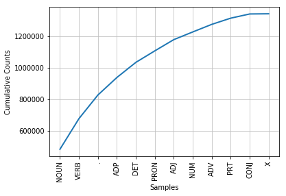

```
  NOUN   VERB      .    ADP    DET   PRON    ADJ    NUM    ADV    PRT   CONJ      X
481943 194458 150320 111197  96123  73238  71415  48775  48081  39501  26559   1155
```

```python
tag_fd = nltk.FreqDist(tag for (word,tag) in false)
tag_fd.most_common()
print("Tag distribution of fakes")
tag_fd.plot(cumulative=True)
tag_fd.tabulate()
```

Grafico che mostra la distribuzione dei tag all'interno degli articoli di categoria 'FAKE'. Si nota come vi è un forte utilizzo della punteggiatura.

```
Tag distribution of trues
```

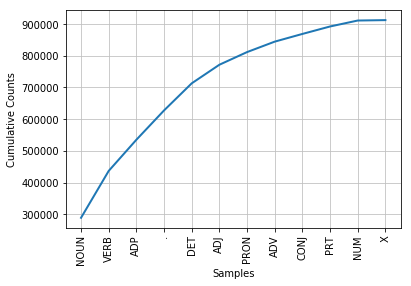

```
  NOUN   VERB    ADP      .    DET    ADJ   PRON    ADV   CONJ    PRT    NUM      X
289315 147806  98207  92440  85365  58634  39867  32924  24276  23501  18736   1307
```

```python
tag_fd = nltk.FreqDist(tag for (word,tag) in true)
tag_fd.most_common()
print("Tag distribution of trues")
tag_fd.plot(cumulative=True)
tag_fd.tabulate()
```

Grafico che mostra la distribuzione dei tag all'interno degli articoli di categoria 'TRUE'.

```python
words = []
for articoli in corpus_tagged:
    for testo in articoli[0]:
        words.append(testo)

listaFreq=nltk.FreqDist(w for w in words)
word_features=[x for (x,_) in listaFreq.most_common()]

def document_features(document,a,b):
    document_words=set(document)
    features={}
    for word in word_features:
        features["contains({})".format(word)]=(word in document_words)
    return features

print("Numero totale parole: {} \nGrandezza dizionario: {}".format(len(words),len(listaFreq)))
```

```
Numero totale parole: 2255143
Grandezza dizionario: 33375
```

Viene creata la lista di frequenze delle parole all'interno del corpus: essa verrà utilizzata nella creazione delle features. Utilizzando una tecnica di POS Tagging, la lunghezza del dizionario è cambiata: da 31907 del primo progetto si arriva a 33375, facendo rimanere invariato il numero di parole totali; in questo modo è aumentato il valore informativo di ogni parola, in quanto è stato differenziato il significato.

```python
featuresets_doc=[(document_features(d,0,len(listaFreq.most_common())), c) for (d, c) in corpus_tagged]
size = int(len(featuresets_doc) * 0.9)
train_set_doc, test_set_doc = featuresets_doc[size:], featuresets_doc[:size]
classifier_doc=nltk.NaiveBayesClassifier.train(train_set_doc)

print("Accuratezza classificazione: {}".format(nltk.classify.accuracy(classifier_doc, test_set_doc)*100))
range_data = nltk.classify.accuracy(classifier_doc, test_set_doc)*100
classifier_doc.show_most_informative_features(10)
```

```
Accuratezza classificazione: 85.99605522682445
Most Informative Features
 contains(sponsor__VERB) = True             fake : legit  =     18.8 : 1.0
       contains(–__NOUN) = True             fake : legit  =     16.2 : 1.0
 contains(hillary__NOUN) = True             fake : legit  =     14.9 : 1.0
  contains(secret__NOUN) = True             fake : legit  =     14.9 : 1.0
  contains(doctor__NOUN) = True             fake : legit  =     13.6 : 1.0
 contains(clinton__NOUN) = True             fake : legit  =     13.6 : 1.0
  contains(weight__NOUN) = True             fake : legit  =     12.3 : 1.0
      contains(no__NOUN) = True             fake : legit  =     12.3 : 1.0
    contains(will__NOUN) = True             fake : legit  =     11.3 : 1.0
  contains(device__NOUN) = True             fake : legit  =     11.0 : 1.0
```

```python
print("Cross validation on 10 fold:")
from sklearn import cross_validation
cv = cross_validation.KFold(len(train_set_doc), n_folds=10, shuffle=False, random_state=None)
i = 1
for traincv, evalcv in cv:
    classifier = nltk.NaiveBayesClassifier.train(train_set_doc[traincv[0]:traincv[len(traincv)-1]])
    print('Accuracy '+str(i)+'° fold: %.3f' % nltk.classify.util.accuracy(classifier, train_set_doc[evalcv[0]:evalcv[len(evalcv)-1]]))
    i = i+1
```

```
Cross validation on 10 fold:
```

```
Accuracy 1° fold: 1.000
Accuracy 2° fold: 0.909
Accuracy 3° fold: 0.727
Accuracy 4° fold: 1.000
Accuracy 5° fold: 1.000
Accuracy 6° fold: 1.000
Accuracy 7° fold: 0.800
Accuracy 8° fold: 1.000
Accuracy 9° fold: 0.900
Accuracy 10° fold: 1.000
```

La cross validation è migliore nel primo progetto nonostante l'accuratezza del classificatore sia migliorata.

## Test sull'accuratezza della classificazione

La frequenza relativa delle parole è stata divisa in slices: partendo da 0 con il primo slice da 500, porzioni da 100 (0-500, 500-600, 600-700 ...) partendo da 0 con il primo slice da 700, porzioni da 100 (0-700, 700-800, 800-900 ...) partendo da 0, slice da 500 incrementali (0-5000, 0-1000, 0,1500 ...) partendo da 0, porzioni da 500 (0-500, 500-1000, 1000-1500 ...) partendo da 0, porzioni da 700 (0-700, 7000-1400, 700-1400 ...) partendo da 0, porzioni da 1000 (0-1000, 1000-2000, 2000-3000 ...)

```python
import matplotlib.pyplot as plt
import pandas as pd

def test_Accuracy(principio, final,parte,veces,caja,incr):
    x = 1
    while(x <= count):
        featuresets_doc=[(document_features(d,principio,final), c) for (d, c) in corpus_tagged]
        size = int(len(featuresets_doc) * 0.9)
        train_set_doc, test_set_doc = featuresets_doc[size:], featuresets_doc[:size]
        classifier_doc=nltk.NaiveBayesClassifier.train(train_set_doc)
        print("\r{}° Range: {} to {} most frequent words, Accuracy: {}".format(x,principio,final,nltk.classify.accuracy(classifier_doc, test_set_doc)*100),end='')
        caja.append(nltk.classify.accuracy(classifier_doc, test_set_doc)*100)
        if (incr==True):
            principio,final = principio+parte,final+parte
        else:
            principio,final = principio,final+parte
        x = x+1
    return caja

def dibujar(caja,count,parte):
    print("\n Grafico 1 in corso...")
    plt.plot(caja,'r')
    plt.xlabel("Range: {} word".format(parte))
    plt.ylabel("Accuracy")
    plt.show()
    print("\n Grafico 2 in corso...")
    plt.plot(caja, 'r--o')
    plt.axis([0,count,10,100])
    plt.xlabel("Range: {} word".format(parte))
    plt.ylabel("Accuracy")
    plt.show()

def document_features(document,principio,final):
    document_words=set(document)
    features={}
    word_features=[x for (x,_) in listaFreq.most_common()[principio:final]]
    for word in word_features:
        features["contains({})".format(word)]=(word in document_words)
    return features
```

```
15° Range: 1400 to 1900 most frequent words, Accuracy: 83.62919132149902
 Grafico 1 in corso...
```

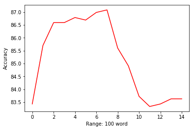

```
 Grafico 2 in corso...
```

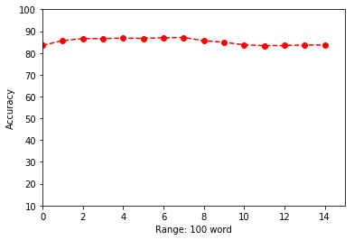

|  | Accuracy Accuracy 0-500 con slice 100 |
| --- | --- |
| 0 | 83.431953 |
| 1 | 85.700197 |
| 2 | 86.587771 |
| 3 | 86.587771 |
| 4 | 86.785010 |
| 5 | 86.686391 |
| 6 | 86.982249 |
| 7 | 87.080868 |
| 8 | 85.601578 |
| 9 | 84.911243 |
| 10 | 83.727811 |
| 11 | 83.333333 |
| 12 | 83.431953 |
| 13 | 83.629191 |
| 14 | 83.629191 |

```python
a = 0
b = 500 # unità di partenza del range
r = 100 # grandezza del range
count = 15
res_s0_e500_r100 = []
dibujar(test_Accuracy(a,b,r,count,res_s0_e500_r100,True),count,r)
pd1 = pd.DataFrame({"Accuracy Accuracy 0-500 con slice 100":res_s0_e500_r100})
pd1
```

```
15° Range: 1400 to 2100 most frequent words, Accuracy: 85.99605522682445
 Grafico 1 in corso...
```

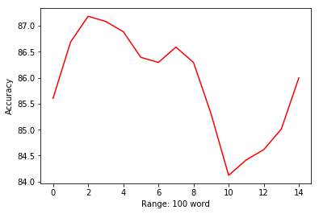

```
 Grafico 2 in corso...
```

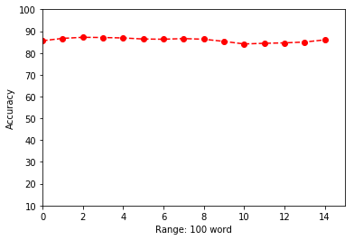

|  | Accuracy 0-700 con slice 100 |
| --- | --- |
| 0 | 85.601578 |
| 1 | 86.686391 |
| 2 | 87.179487 |
| 3 | 87.080868 |
| 4 | 86.883629 |
| 5 | 86.390533 |
| 6 | 86.291913 |
| 7 | 86.587771 |
| 8 | 86.291913 |
| 9 | 85.305720 |
| 10 | 84.122288 |
| 11 | 84.418146 |
| 12 | 84.615385 |
| 13 | 85.009862 |
| 14 | 85.996055 |

```python
a = 0
b = 700 # unità di partenza del range
r = 100 # grandezza del range
count = 15
res_s0_e700_r100 = []
dibujar(test_Accuracy(a,b,r,count,res_s0_e700_r100,True),count,r)
pd2 = pd.DataFrame({"Accuracy 0-700 con slice 100":res_s0_e700_r100})
pd2
```

```
15° Range: 0 to 7500 most frequent words, Accuracy: 87.17948717948718
 Grafico 1 in corso...
```

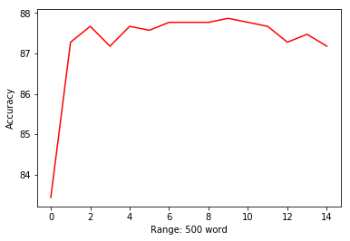

```
 Grafico 2 in corso...
```

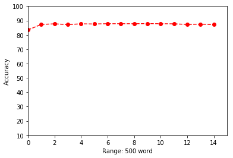

|  | Accuracy 0-500 con slice 500 incrementale |
| --- | --- |
| 0 | 83.431953 |
| 1 | 87.278107 |
| 2 | 87.672584 |
| 3 | 87.179487 |
| 4 | 87.672584 |
| 5 | 87.573964 |
| 6 | 87.771203 |
| 7 | 87.771203 |
| 8 | 87.771203 |
| 9 | 87.869822 |
| 10 | 87.771203 |
| 11 | 87.672584 |
| 12 | 87.278107 |
| 13 | 87.475345 |
| 14 | 87.179487 |

```python
a = 0
b = 500 # unità di partenza del range
r = 500 # grandezza del range
count = 15
res_s0_e500_r500_incremental = []
dibujar(test_Accuracy(a,b,r,count,res_s0_e500_r500_incremental,False),count,r)
pd3 = pd.DataFrame({"Accuracy 0-500 con slice 500 incrementale":res_s0_e500_r500_incremental})
pd3
```

```
15° Range: 7000 to 7500 most frequent words, Accuracy: 68.04733727810651
 Grafico 1 in corso...
```

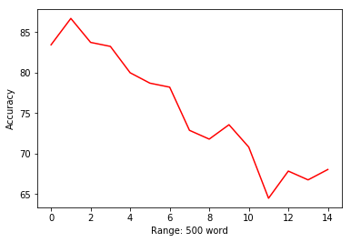

```
 Grafico 2 in corso...
```

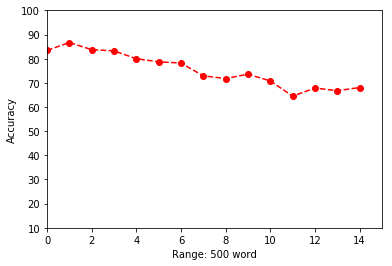

|  | Accuracy 0-500 con slice di 500 |
| --- | --- |
| 0 | 83.431953 |
| 1 | 86.686391 |
| 2 | 83.727811 |
| 3 | 83.234714 |
| 4 | 79.980276 |
| 5 | 78.698225 |
| 6 | 78.205128 |
| 7 | 72.879684 |
| 8 | 71.794872 |
| 9 | 73.570020 |
| 10 | 70.808679 |
| 11 | 64.497041 |
| 12 | 67.850099 |
| 13 | 66.765286 |
| 14 | 68.047337 |

```python
a = 0
b = 500 # unità di partenza del range
r = 500 # grandezza del range
count = 15
res_s0_e500_r500 = []
dibujar(test_Accuracy(a,b,r,count,res_s0_e500_r500,True),count,r)
pd4 = pd.DataFrame({"Accuracy 0-500 con slice di 500":res_s0_e500_r500})
pd4
```

```
15° Range: 9800 to 10500 most frequent words, Accuracy: 68.93491124260355
 Grafico 1 in corso...
```

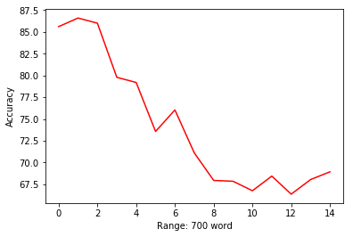

```
 Grafico 2 in corso...
```

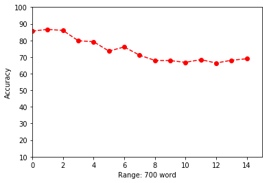

|  | Accuracy 0-700 con slice di 700 |
| --- | --- |
| 0 | 85.601578 |
| 1 | 86.587771 |
| 2 | 85.996055 |
| 3 | 79.783037 |
| 4 | 79.191321 |
| 5 | 73.570020 |
| 6 | 76.035503 |
| 7 | 71.104536 |
| 8 | 67.948718 |
| 9 | 67.850099 |
| 10 | 66.765286 |
| 11 | 68.441815 |
| 12 | 66.370809 |
| 13 | 68.047337 |
| 14 | 68.934911 |

```python
a = 0
b = 700 # unità di partenza del range
r = 700 # grandezza del range
count = 15
res_s0_e700_r700 = []
dibujar(test_Accuracy(a,b,r,count,res_s0_e700_r700,True),count,r)
pd5 = pd.DataFrame({"Accuracy 0-700 con slice di 700":res_s0_e700_r700})
pd5
```

```
15° Range: 14000 to 15000 most frequent words, Accuracy: 49.60552268244576
 Grafico 1 in corso...
```

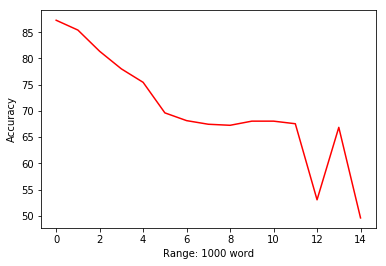

```
 Grafico 2 in corso...
```

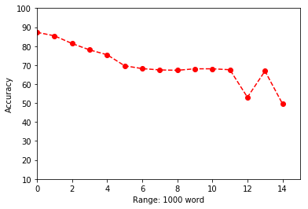

|  | Accuracy 0-1000 con slice di 1000 |
| --- | --- |
| 0 | 87.278107 |
| 1 | 85.404339 |
| 2 | 81.360947 |
| 3 | 78.007890 |
| 4 | 75.443787 |
| 5 | 69.625247 |
| 6 | 68.145957 |
| 7 | 67.455621 |
| 8 | 67.258383 |
| 9 | 68.047337 |
| 10 | 68.047337 |
| 11 | 67.554241 |
| 12 | 53.057199 |
| 13 | 66.863905 |
| 14 | 49.605523 |

```python
a = 0
b = 1000 # unità di partenza del range
r = 1000 # grandezza del range
count = 15
res_s0_e1000_r1000 = []
dibujar(test_Accuracy(a,b,r,count,res_s0_e1000_r1000,True),count,r)
pd6 = pd.DataFrame({"Accuracy 0-1000 con slice di 1000":res_s0_e1000_r1000})
pd6
```

```python
pd1.join(pd2).join(pd3).join(pd4).join(pd5).join(pd6)
```

|  | Accuracy Accuracy 0-500 con slice 100 | Accuracy 0-700 con slice 100 | Accuracy 0-500 con slice 500 incrementale | Accuracy 0-500 con slice di 500 | Accuracy 0-700 con slice di 700 | Accuracy 0-1000 con slice di 1000 |
| --- | --- | --- | --- | --- | --- | --- |
| 0 | 83.431953 | 85.601578 | 83.431953 | 83.431953 | 85.601578 | 87.278107 |
| 1 | 85.700197 | 86.686391 | 87.278107 | 86.686391 | 86.587771 | 85.404339 |
| 2 | 86.587771 | 87.179487 | 87.672584 | 83.727811 | 85.996055 | 81.360947 |
| 3 | 86.587771 | 87.080868 | 87.179487 | 83.234714 | 79.783037 | 78.007890 |
| 4 | 86.785010 | 86.883629 | 87.672584 | 79.980276 | 79.191321 | 75.443787 |
| 5 | 86.686391 | 86.390533 | 87.573964 | 78.698225 | 73.570020 | 69.625247 |
| 6 | 86.982249 | 86.291913 | 87.771203 | 78.205128 | 76.035503 | 68.145957 |
| 7 | 87.080868 | 86.587771 | 87.771203 | 72.879684 | 71.104536 | 67.455621 |
| 8 | 85.601578 | 86.291913 | 87.771203 | 71.794872 | 67.948718 | 67.258383 |
| 9 | 84.911243 | 85.305720 | 87.869822 | 73.570020 | 67.850099 | 68.047337 |
| 10 | 83.727811 | 84.122288 | 87.771203 | 70.808679 | 66.765286 | 68.047337 |
| 11 | 83.333333 | 84.418146 | 87.672584 | 64.497041 | 68.441815 | 67.554241 |
| 12 | 83.431953 | 84.615385 | 87.278107 | 67.850099 | 66.370809 | 53.057199 |
| 13 | 83.629191 | 85.009862 | 87.475345 | 66.765286 | 68.047337 | 66.863905 |
| 14 | 83.629191 | 85.996055 | 87.179487 | 68.047337 | 68.934911 | 49.605523 |

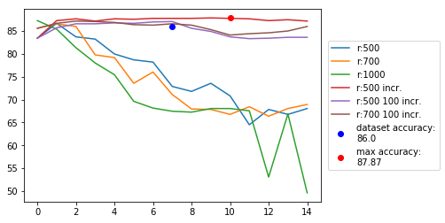

```python
import matplotlib.pyplot as plt
import numpy as np
p = res_s0_e500_r500 + res_s0_e700_r700 + res_s0_e1000_r1000 + res_s0_e500_r500_incremental + res_s0_e500_r100 + res_s0_e700_r100

maximo = 0
for i in p:
    if (i > maximo):
        maximo = i

fig = plt.figure(1)
ax = fig.add_subplot(111)
plt.title('Testing Accuracy POS')
ax.plot(res_s0_e500_r500, label='r:500')
ax.plot(res_s0_e700_r700, label='r:700')
ax.plot(res_s0_e1000_r1000, label='r:1000')
ax.plot(res_s0_e500_r500_incremental, label='r:500 incr.')
ax.plot(res_s0_e500_r100, label='r:500 100 incr.')
ax.plot(res_s0_e700_r100, label='r:700 100 incr.')
ax.plot(7,range_data,'bo', label='dataset accuracy:\n{}'.format(round(range_data,2)))
ax.plot(10,maximo,'ro', label='max accuracy:\n{}'.format(round(maximo,2)))
handles,labels = ax.get_legend_handles_labels()
lgd = ax.legend(handles,labels,loc='right', bbox_to_anchor=(1.4,0.5),borderaxespad=0)
plt.show()

fig.savefig("Testing_Accuracy_POS",bbox_extra_artists=(lgd,), bbox_inches='tight')
```

Il grafico mostra come, allontanandosi dalle feature iniziali, l'accuratezza diminuisce, mentre gli slice di accuratezza migliore considerano parole ad alta frequenza. Il risultato di questo 'slicing' ci porta ad osservare che l'accuratezza migliore è di 87.87% riscontrata nella sezione 0-5000.

```python
def document_featureshuffle(document,principio,final):
    document_words=set(document)
    features={}
    word_features=[x for (x,_) in listaFreq.most_common()[principio:final]]
    random.shuffle(word_features)
    random.shuffle(word_features)
    for word in word_features:
        features["contains({})".format(word)]=(word in document_words)
    return features
```

```python
begin = 0
final = 5000
final_more = []
final_less = []


begin_more = []
begin_less = []
count = 10
hace = True
jump = 50
if (begin==0):
    hace = False
i = 1
print("\nFrom {} to {}: from the end up to {} words".format(begin,final,jump))
while i <= count:
    featuresets_doc=[(document_featureshuffle(d,begin,final), c) for (d, c) in corpus_tagged]
    size = int(len(featuresets_doc) * 0.9)
    train_set_doc, test_set_doc = featuresets_doc[size:], featuresets_doc[:size]
    classifier_doc=nltk.NaiveBayesClassifier.train(train_set_doc)
    print("\r{}° slice: from {} to {}, accuracy: {}".format(i,begin,final,nltk.classify.accuracy(classifier_doc, test_set_doc)*100),end='')
    final_more.append(nltk.classify.accuracy(classifier_doc, test_set_doc)*100)
    final = final + jump
    i = i+1
pd_end_up = pd.DataFrame({"Accuracy end up to 50":final_more})

begin = 0
final = 5000
i = 1
print("\nFrom {} to {}: from the end down to {} words".format(final,begin,jump))
while i <= count:
    featuresets_doc=[(document_featureshuffle(d,begin,final), c) for (d, c) in corpus_tagged]
    size = int(len(featuresets_doc) * 0.9)
    train_set_doc, test_set_doc = featuresets_doc[size:], featuresets_doc[:size]
    classifier_doc=nltk.NaiveBayesClassifier.train(train_set_doc)
    print("\r{}° slice: from {} to {}, accuracy: {}".format(i,begin,final,nltk.classify.accuracy(classifier_doc,test_set_doc)*100),end='')
    final_less.append(nltk.classify.accuracy(classifier_doc, test_set_doc)*100)
    final = final - jump
    i = i+1
pd_end_down = pd.DataFrame({"Accuracy end down to 50":final_less})

begin = 0
final = 5000
i = 1
print("\nFrom {} to {}: from the beginning up to {} words".format(begin,final,jump))
while i <= count:
    featuresets_doc=[(document_featureshuffle(d,begin,final), c) for (d, c) in corpus_tagged]
    size = int(len(featuresets_doc) * 0.9)
    train_set_doc, test_set_doc = featuresets_doc[size:], featuresets_doc[:size]
    classifier_doc=nltk.NaiveBayesClassifier.train(train_set_doc)
    print("\r{}° slice: from {} to {}, accuracy: {}".format(i,begin,final,nltk.classify.accuracy(classifier_doc, test_set_doc)*100),end='')
    begin_more.append(nltk.classify.accuracy(classifier_doc, test_set_doc)*100)
    begin = begin + 50
    i = i+1
pd_begin_up = pd.DataFrame({"Accuracy begin up to 50":begin_more})

begin = 0
final = 5000
i = 1
if (hace):
    print("\nFrom {} to {}: from the beginning down of {} words".format(final,begin - jump*10,jump))
    while i <= count:
            featuresets_doc=[(document_featureshuffle(d,begin,final), c) for (d, c) in corpus_tagged]
            size = int(len(featuresets_doc) * 0.9)
            train_set_doc, test_set_doc = featuresets_doc[size:], featuresets_doc[:size]
            classifier_doc=nltk.NaiveBayesClassifier.train(train_set_doc)
            print("\r{}° slice: from {} to {}, accuracy: {}".format(i,begin,final,nltk.classify.accuracy(classifier_doc, test_set_doc)*100),end='')
            begin_less.append(nltk.classify.accuracy(classifier_doc, test_set_doc)*100)
            begin = begin - 50
            i = i+1
    pd_begin_down = pd.DataFrame({"Accuracy begin down to 50":begin_less})
else:
    pd_begin_down = pd.DataFrame({"Accuracy begin down to 50":[]})
```

```
From 0 to 5000: from the end up to 50 words
10° slice: from 0 to 5450, accuracy: 87.67258382642999
From 5000 to 0: from the end down to 50 words
10° slice: from 0 to 4550, accuracy: 87.77120315581854
From 0 to 5000: from the beginning up to 50 words
10° slice: from 450 to 5000, accuracy: 86.29191321499013
```

```python
pd_end_up.join(pd_end_down).join(pd_begin_up).join(pd_begin_down)
```

|  | Accuracy end up to 50 | Accuracy end down to 50 | Accuracy begin up to 50 | Accuracy begin down to 50 |
| --- | --- | --- | --- | --- |
| 0 | 87.869822 | 87.869822 | 87.869822 | NaN |
| 1 | 87.869822 | 87.869822 | 86.489152 | NaN |
| 2 | 87.869822 | 87.869822 | 86.587771 | NaN |
| 3 | 87.869822 | 87.869822 | 86.686391 | NaN |
| 4 | 87.869822 | 87.869822 | 86.587771 | NaN |
| 5 | 87.771203 | 87.968442 | 86.489152 | NaN |
| 6 | 87.771203 | 87.869822 | 86.390533 | NaN |
| 7 | 87.771203 | 87.869822 | 86.094675 | NaN |
| 8 | 87.771203 | 87.869822 | 86.193294 | NaN |
| 9 | 87.672584 | 87.771203 | 86.291913 | NaN |

L'obbiettivo qui è quello di controllare, a scaglioni di 50 freq, di quanto l'accuratezza varia, in modo da avere una porzione ancora migliore.

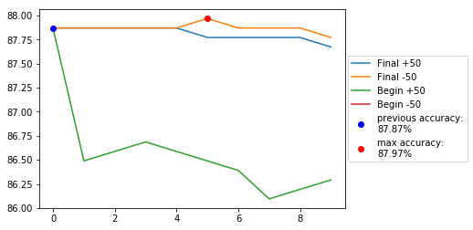

```python
import matplotlib.pyplot as plt
import numpy as np
p_ =  final_more+final_less+begin_more+begin_less

maximo_ = 0
for i in p_:
    if (i > maximo_):
        maximo_ = i

fig = plt.figure(1)
ax = fig.add_subplot(111)
plt.title('Adjust Accuracy POS')
ax.plot(final_more, label="Final +50")
ax.plot(final_less, label="Final -50")
ax.plot(begin_more, label="Begin +50")
ax.plot(begin_less, label="Begin -50")

ax.plot(0,maximo,'bo', label='previous accuracy:\n{}%'.format(round(maximo,2)))
ax.plot(5,maximo_,'ro', label='max accuracy:\n{}%'.format(round(maximo_,2)))

handles,labels = ax.get_legend_handles_labels()
lgd = ax.legend(handles,labels,loc='right', bbox_to_anchor=(1.4,0.5),borderaxespad=0)
plt.show()

fig.savefig("Adjust_Accuracy_POS",bbox_extra_artists=(lgd,), bbox_inches='tight', dpi=400) #dpi 400 metto per tutte le figure
```

```python
def document_featureshuffle(document,begin,end):
    document_words=set(document)
    features={}
    random.shuffle(document)
    for word in document[begin:end]:
        features["contains({})".format(word)]=(word in document_words)
    return features

def test_accuracy(caja,range_,begin,end,count):
    count_ = 1
    while count_ <= count:
        featuresets_doc=[(document_featureshuffle(word_features,begin,end), c) for (d, c) in corpus_tagged]
        size = int(len(featuresets_doc) * 0.9)
        train_set_doc, test_set_doc = featuresets_doc[size:], featuresets_doc[:size]
        classifier_doc=nltk.NaiveBayesClassifier.train(train_set_doc)
        print("\r{}° accuracy from {} to {} is {} updating...".format(count_,begin,end,nltk.classify.accuracy(classifier_doc, test_set_doc)*100),end="")
        caja.append(nltk.classify.accuracy(classifier_doc, test_set_doc)*100)
        begin, end = end, end+range_
        count_ = count_ +1

import pandas as pd
word_features=[x for (x,_) in listaFreq.most_common()[0:1500]] ###ricordarsi che qua bisogna cambiare!!
random.shuffle(word_features)
random.shuffle(word_features)

res_50 = []
r = 50
begin = 0
end = 50
print("Accuracy hitting 50 slices:")
test_accuracy(res_50,r,begin,end,10)
pd50 = pd.DataFrame({"Accuracy 50":res_50})

res_100 = []
r = 100
begin = 0
end = 100
print("\nAccuracy hitting 100 slices:")
test_accuracy(res_100,r,begin,end,10)
pd100 = pd.DataFrame({"Accuracy 100":res_100})

res_150 = []
r = 150
begin = 0
end = 150
print("\nAccuracy hitting 150 slices:")
test_accuracy(res_150,r,begin,end,10)
pd150 = pd.DataFrame({"Accuracy 150":res_150})

res_200 = []
r = 200
begin = 0
end = 200
print("\nAccuracy hitting 200 slices:")
test_accuracy(res_200,r,begin,end,10)
pd200 = pd.DataFrame({"Accuracy 200":res_200})

res_250 = []
r = 250
begin = 0
end = 250
print("\nAccuracy hitting 250 slices:")
test_accuracy(res_250,r,begin,end,10)
pd250 = pd.DataFrame({"Accuracy 250":res_250})

pd50.join(pd100).join(pd150).join(pd200).join(pd250)
```

```
Accuracy hitting 50 slices:
10° accuracy from 450 to 500 is 42.11045364891518 updating...
Accuracy hitting 100 slices:
10° accuracy from 900 to 1000 is 52.16962524654832 updating...
Accuracy hitting 150 slices:
10° accuracy from 1350 to 1500 is 56.11439842209073 updating...
Accuracy hitting 200 slices:
10° accuracy from 1800 to 2000 is 66.5680473372781 updating....
Accuracy hitting 250 slices:
10° accuracy from 2250 to 2500 is 66.5680473372781 updating....
```

|  | Accuracy 50 | Accuracy 100 | Accuracy 150 | Accuracy 200 | Accuracy 250 |
| --- | --- | --- | --- | --- | --- |
| 0 | 43.984221 | 49.802761 | 54.437870 | 55.029586 | 52.071006 |
| 1 | 44.575937 | 48.323471 | 53.254438 | 54.043393 | 51.972387 |
| 2 | 42.998028 | 50.690335 | 54.339250 | 54.733728 | 56.311637 |
| 3 | 47.140039 | 50.098619 | 53.944773 | 53.846154 | 55.719921 |
| 4 | 46.449704 | 53.057199 | 56.213018 | 52.958580 | 53.846154 |
| 5 | 45.069034 | 49.013807 | 51.183432 | 57.396450 | 55.522682 |
| 6 | 43.392505 | 50.000000 | 55.128205 | 56.706114 | 66.568047 |
| 7 | 45.956607 | 52.366864 | 52.564103 | 47.534517 | 66.568047 |
| 8 | 43.491124 | 50.295858 | 54.339250 | 66.568047 | 66.568047 |
| 9 | 42.110454 | 52.169625 | 56.114398 | 66.568047 | 66.568047 |

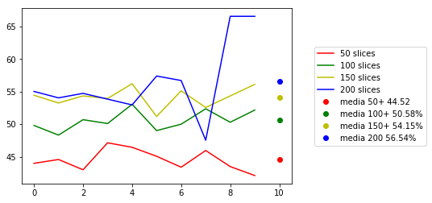

```python
import matplotlib.pyplot as plt
import numpy as np


media50 = sum(res_50)/len(res_50)
media100 = sum(res_100)/len(res_100)
media150 = sum(res_150)/len(res_150)
media200 = sum(res_200)/len(res_200)

fig = plt.figure(1)
ax = fig.add_subplot(111)
plt.title('Best Slice Accuracy POS')
ax.plot(res_50,"r",label="50 slices")
ax.plot(res_100,"g", label="100 slices")
ax.plot(res_150,"y", label="150 slices")
ax.plot(res_200,"b", label="200 slices")
ax.plot(10,media50,"or", label="media 50+ {}".format(round(media50,2)))
ax.plot(10,media100,"og",label="media 100+ {}%".format(round(media100,2)))
ax.plot(10,media150,"oy",label="media 150+ {}%".format(round(media150,2)))
ax.plot(10,media200,"ob",label="media 200 {}%".format(round(media200,2)))

handles,labels = ax.get_legend_handles_labels()
lgd = ax.legend(handles,labels,loc='right', bbox_to_anchor=(1.5,0.5),borderaxespad=0)
plt.show()

fig.savefig("Slice_Accuracy_POS",bbox_extra_artists=(lgd,), bbox_inches='tight')
```

Aumentando lo slice di feature, aumenta anche l'accuratezza indistintamente.

In conclusione: analizzando l'andamento dell'accuratezza della classificazione, si nota come la finestra con l'accuratezza maggiore si abbia nello slice di frequenze 0:4750. Analizzando lo slice, si nota come aumentando la finestra, si aumenti l'accuratezza del classificatore: non si ha quindi una finestra di feature ideale all'interno dello slice con la massima accuratezza.

Si è dimostrato come il preprocessing aumenti l'accuratezza della classificazione, e si è concluso che le parole più utili per la differenziazione tra fake news e legit news si trovano nello slice 0:4750 del dataset.